# Lecture 30

May 9, 2016

## Today's Example

The parameter of interest is \(p\): probability of flipping heads.

- We believe beforehand that \(p=0.5\).
- Our data says however \(\widehat{p}=0.8\), suggesting \(p=0.8\).

## Prior Distribution

The prior distribution reflects our **degree of belief** in different values of \(p\):

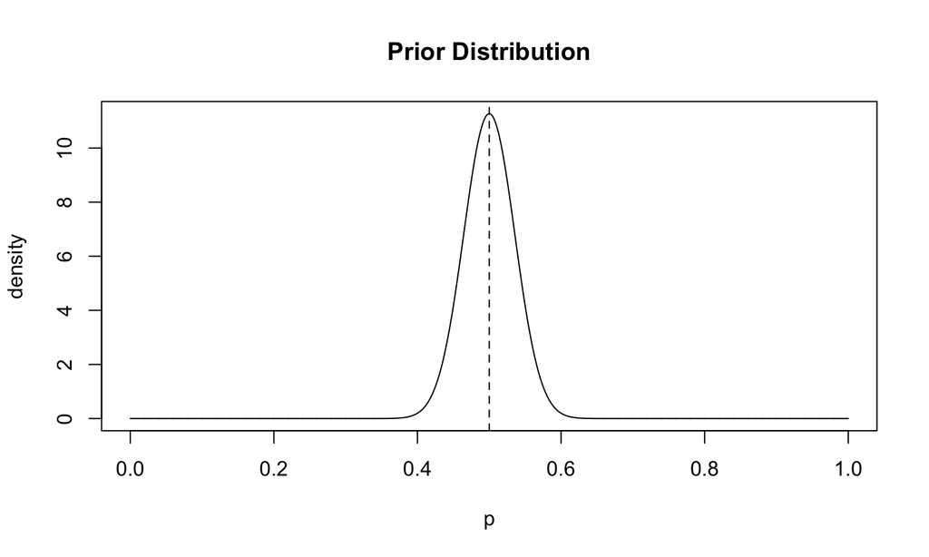

## Likelihood Function

We flip a coin \(n=20\) times and observe \(16\) heads. The likelihood function along with the MLE \(\widehat{p}=0.8\) of \(p\) is:

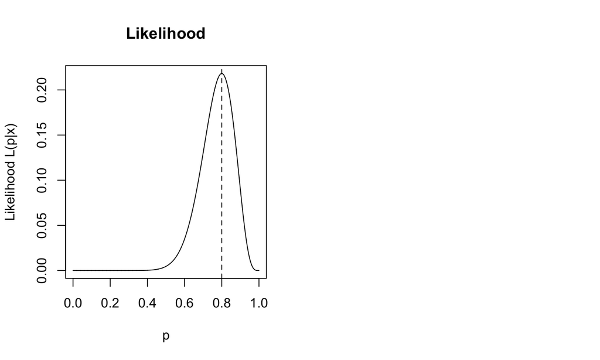

## Prior + Likelihood = Posterior

We can then compute the posterior on the right:

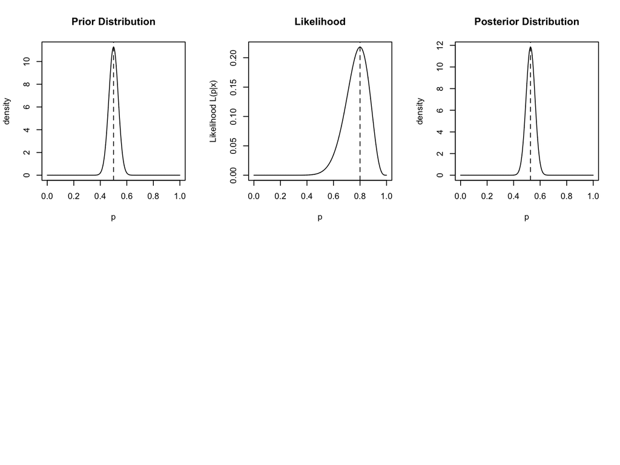

## Two Comparisons

- Different priors centered at \(p=0.5\), but one with
  - High prior certainty
  - Low prior certainty
- Different likelihood functions where \(\widehat{p}=0.8\) but
  - \(n=20\) and \(16\) heads
  - \(n=100\) and \(80\) heads

## Comparison 1: Different Prior

Here, the red prior is less certain that \(p=0.5\)

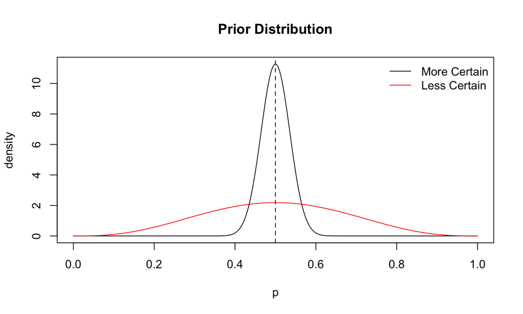

## Comparison 1: Different Prior

What does the posterior (with same likelihood) look like?

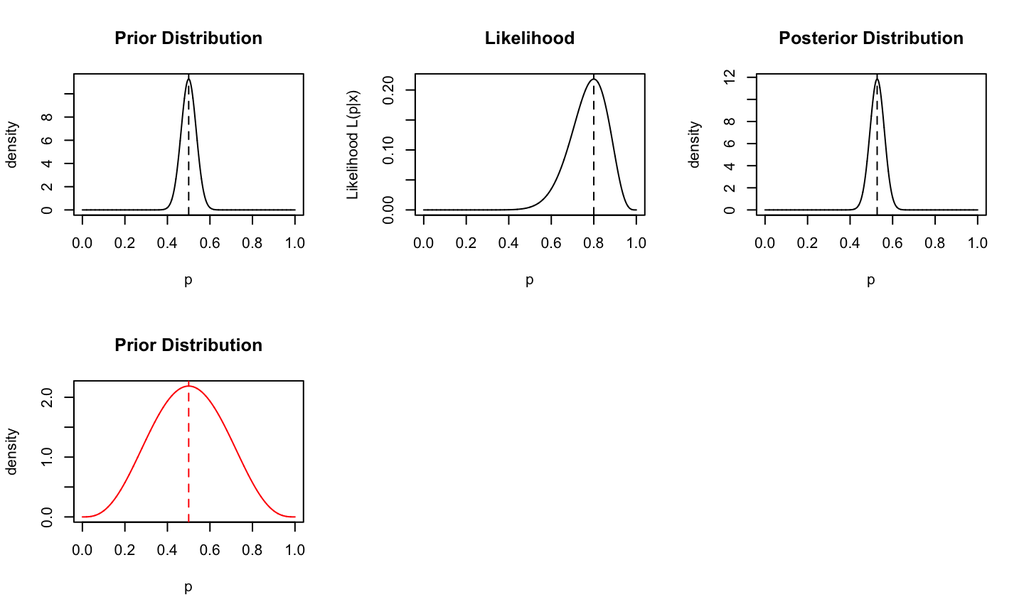

## Comparison 1: Different Prior

The posterior in the bottom shifted to the right more.

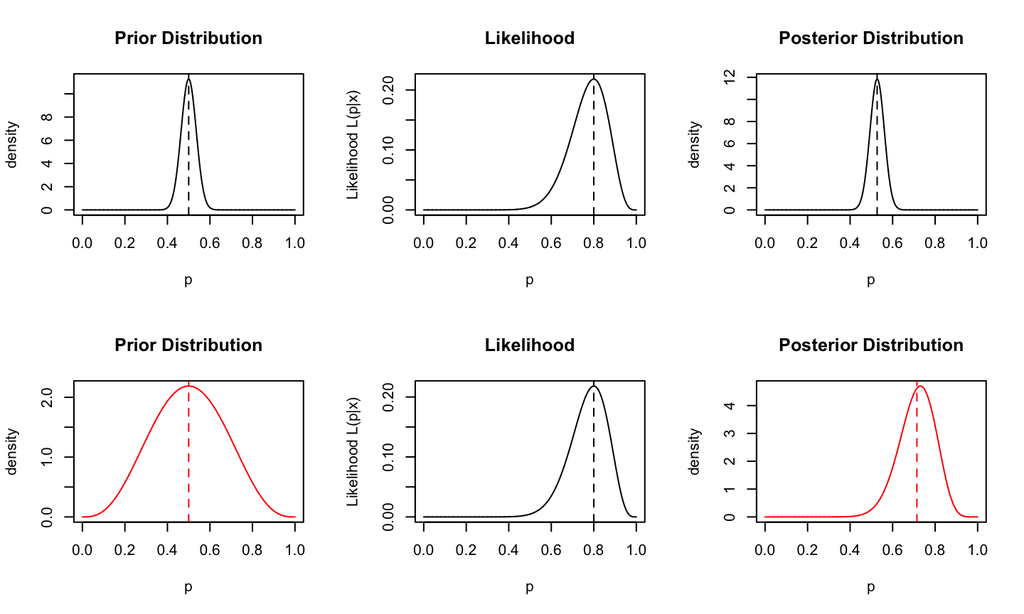

## Comparison 2: Different Likelihood

Now let the red curve reflect \(n=100\) flips and \(80\) heads. Note that the likelihood function is more tight around 0.8.

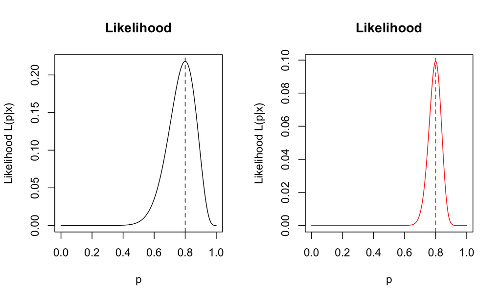

## Comparison 2: Different Likelihood

What does the posterior (with same prior) look like?

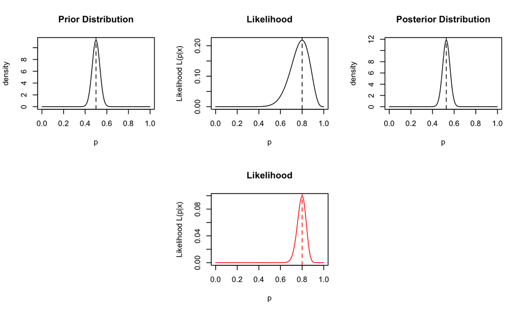

## Comparison 2: Different Likelihood

The posterior in the bottom shifted to the right more.

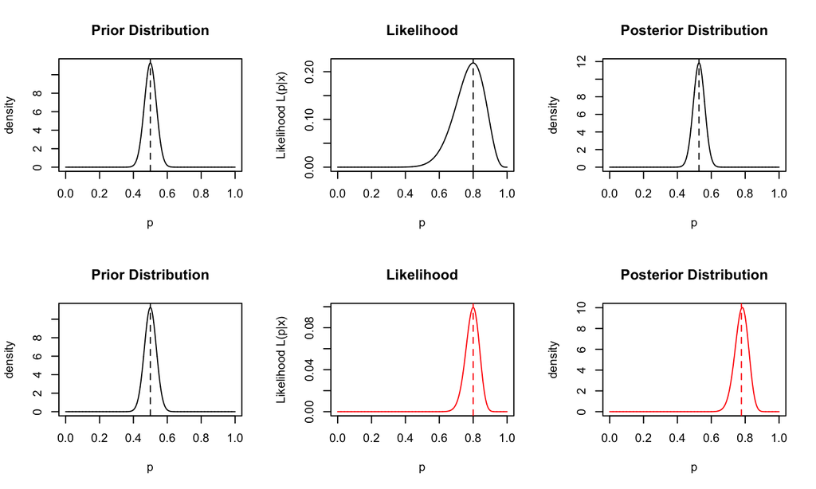